# AOOI3_Aula05_DiagramasDeCasoDeUso

Instituto Federal de São Paulo (IFSP)  
[Campus Bragança Paulista/SP](https://bra.ifsp.edu.br)  
**Análise e Desenvolvimento de Sistemas (ADS)**  
**3o. módulo**  
**Profa. Ana Paula Müller Giancoli**  
paulagiancoli@ifsp.edu.br

## AULA 05 - DIAGRAMAS DE CASO DE USO

### Agenda

- Diagramas de Caso de Uso
  - Definição
  - Objetivo
  - Componentes
  - Modelo
  - Atores
  - Relacionamentos
  - Tipos de caso de uso
- Especificações de Caso de Uso
- Perguntas

### 1. Caso de Uso

- Definição de um caso de uso segundo Jacobson: ...”**documento narrativo que descreve a sequência de eventos de um ator que usa um sistema para completar um processo**.”
- É uma **técnica de modelagem** usada para descrever o que um novo sistema deverá fazer.
- É **construído através de um processo interativo** no qual as discussões entre o cliente e os desenvolvedores do sistema conduzem a uma especificação do sistema da qual todos estão de acordo.

### 1.1. Definição

- **Descreve as operações que o sistema deve cumprir para cada usuário**.
- **Formaliza as funções** que o sistema precisa fazer.
- Um caso de uso se apresenta como uma **lista completa das interações** entre um usuário e o sistema para cumprir uma tarefa.
  - **Lista completa**: significa que o caso de uso descreve as interações desde o início da tarefa, até o fim.
- Os casos de uso **devem ser compreensíveis** por usuários porque somente eles, sabem o que o sistema precisa fazer.
- Os casos de uso **permitem verificar** se o desenvolvedor e o usuário concordam sobre o que o sistema deve fazer. Isso é um item que deve ter a atenção.
- Ao mesmo tempo, casos de uso podem servir de **"contratos"** entre os usuários e a equipe de desenvolvimento.

### 1.2. Objetivos

- O caso de uso tem por **OBJETIVOS**:
  - Decidir e descrever os requisitos funcionais do sistema.
  - Fornecer uma descrição clara e consistente do que o sistema deve fazer.
  - Permitir descobrir os requisitos funcionais das classes e operações do sistema.
- **Observação**: **(Casos de uso NÃO são requisitos)**

### 1.3. Componentes de um Modelo de Caso de Uso

- São dois elementos: ator e caso de uso.
  - **Ator**:
    - É um papel que tipicamente estimula/solicita ações/ eventos do sistema e recebe reações.
    - Cada ator pode participar de um ou vários casos de uso.
    - Um ator poderá ser uma pessoa, um sistema externo ou Entidade Externa (análise estruturada).
  - **Caso de uso**:
    - a elipse é a notação de um caso de uso.
    - O caso de uso é uma **ATIVIDADE**, é a macro ação que o ator realiza.

### 1.4. Modelo de Caso de Uso

- Na Linguagem de Modelagem Unificada (UML), o modelo de casos de uso consiste de diagramas de casos de uso que exibem os atores, os casos de uso e seus relacionamentos.
- Os elementos gráficos que representam atores, casos de uso e sistema são mostrados a seguir:

**Figura 1: Elementos essenciais do Modelo do Diagrama de Caso de Uso**

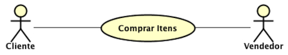

Fonte: Autoria própria

### 1.4.1. Exemplo de um Diagrama de Caso de Uso

**Figura 2: Diagrama de Caso de Uso**

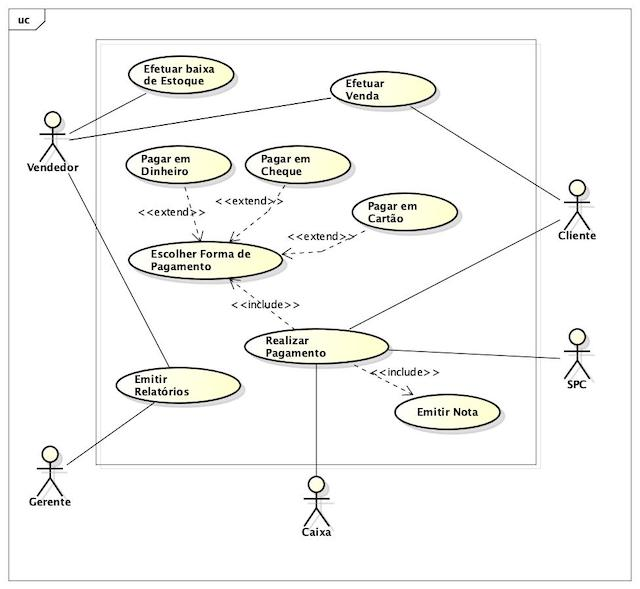

Fonte: Autoria própria

### 1.5. Atores

- O **Ator é sempre externo ao Sistema**.
- Pode exercer diversos papéis seja um ser humano, hardware externo, outros sistemas e etc.
- No modelo, além do nome, que deve exprimir claramente o seu papel, todo Ator deve possuir uma breve descrição, especificando suas responsabilidades e também, o que ele precisa do sistema.
- São de dois tipos:
  - **Ator Primário**:
    - **É o interessado que acessa o sistema para entregar-lhe diretamente um serviço**. Quase sempre é ele quem inicia um caso de uso, como, por exemplo, um balconista que acessa o sistema em nome do cliente.
  - **Ator Secundário**:
    - Conhecido também como, **Ator de suporte** é **um interessado que provê um serviço ao sistema, mas não diretamente**, como por exemplo, uma impressora, um serviço de internet, etc. São úteis para identificar o que o sistema deverá prover em termos de formatos de dados e interfaces externas etc.
  - **Observação**:
    - **Um Ator pode ser primário em um caso de uso e ser secundário em outro**.

### 1.5.1. Como identificar atores ?

- **Problema**: Como identifi car os atores que irão participar do modelo? Devemos então, fazer as seguintes perguntas:
  - 1.Quem usa o sistema?
  - 2.Quem inicia o sistema?
  - 3.Quem fornece os dados?
  - 4.Quem usa as informações?

### 1.5.2. Como descrever atores ?

- **Problema**: Como descrever os atores que interagem com o sistema? Geralmente descrevemos atores usando:
  - Nome do caso de uso, tipo de uso (frequente, ocasional, etc...) descrição de seu papel no sistema.

### 1.5.3. Como identificar os casos de uso ?

- **Problema**: Como identificar os casos de uso do sistema?
  - Os casos de uso são interações entre os atores e o sistema.
  - Logo, temos ações do ator e ações do sistema. Sendo que os atores sempre iniciam a ação.
  - Os atores são fundamentais para a descoberta dos casos de uso.
- **Pergunte**: Qual o objetivo de cada ator com o sistema?
  - 1.O sistema armazena informações?
  - 2.Quais informações os atores irão criar, ler, atualizar ou apagar?
  - 3.O sistema precisa notificar o ator sobre mudanças no seu estado interno?
  - 4.Existe algum evento externo que o sistema precisa saber?
  - 5.Que ator informa o sistema destes eventos?

### Exemplos

**Figura 3: Tipos de Relacionamentos do Diagrama de Caso de Uso**

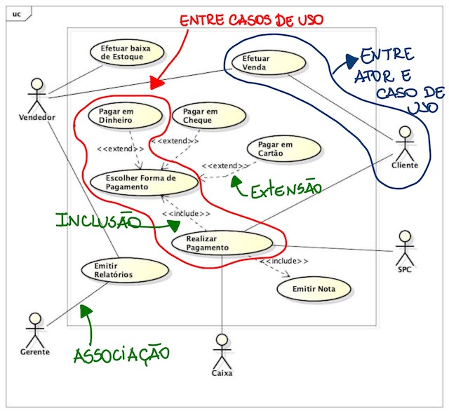

Fonte: Autoria própria

### 1.6.1. Associação

- É a participação de um Ator em um Caso de Uso.
- Exibe a comunicação entre as instâncias do ator com as instâncias do Caso de Uso.
  - **Exemplo**: Um Vendedor (ator) pode colocar um ou mais pedidos (Caso de Uso).
  - **Representação**: é feita por uma linha sólida entre o Ator e o Caso de Uso.

**Figura 4: Relacionamento de Associação de Diagrama de Caso de Uso**

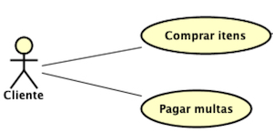

Fonte: Autoria própria

### 1.6.2. Extend (Extensão)

- Um relacionamento de extensão de um caso de uso para outro indica que a instância do primeiro pode ser acrescentada pelo comportamento definido no segundo caso de uso, denominado Caso de Uso de Extensão.
  - **Exemplo**: Um Vendedor (ator) pode colocar um ou mais pedidos (caso de uso) e consultar um catálogo de produtos (caso de uso) (opcional, ou melhor, mediante seleção, escolha.).
  - **Representação**: é feita por uma linha tracejada com uma seta apontando para o Caso de Uso estendido e rotulada com a palavra - extend - .
- O caso de uso estendido (Criar pedidos) é denominado Caso de Uso Básico.
- O caso de uso que estende (Consultar catálogo de itens) é denominado Caso de Uso de Extensão. Itens que podem ser adicionados ao pedido mediante escolha do ator.

**Figura 5: Relacionamento de Extend de Diagrama de Caso de Uso**

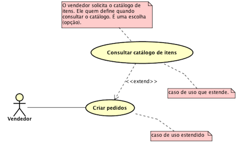

Fonte: Autoria própria

### 1.6.3. Include (Inclusão)

- Um relacionamento de inclusão de um caso de uso para outro indica que a instância do primeiro também conterá o comportamento especificado pelo segundo, denominado Caso de Uso de Inclusão.
  - **Exemplo**: Serão sempre executados quando um pedido for colocado (Obrigatoriamente).
  - **Representação**: é feita por uma linha tracejada com uma seta apontando para o Caso de Uso incluído e rotulada com a palavra - include - .
- O caso de uso que inclui (Criar pedidos) é denominado Caso de Uso Básico.
- O caso de uso incluído (Inserir informações do cliente e Inserir itens ao pedido) são denominados Caso de Uso de Inclusão. São informações do cliente que obrigatoriamente serão solicitadas, bem como itens que serão inseridos ao pedido.

**Figura 6: Relacionamento de Include de Diagrama de Caso de Uso**

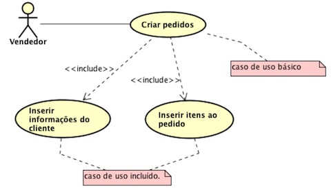

Fonte: Autoria própria

### 1.6.4. Generalização ou Herança

- Um relacionamento de generalização de caso de uso para outro indica que o primeiro é uma especialização do segundo.
- **Representação**: é feita por uma linha sólida com uma seta fechada apontando para o caso de uso pai.

**Figura 7: Relacionamento de Herança de Diagrama de Caso de Uso**

[figure not shown]

Fonte: Autoria própria

### 1.7.1. Tipos de Caso de Uso

- Podem ser classificados em dois tipos:
  - **Caso de uso Concreto**: **é iniciado por um ator** e representa um fluxo completo de eventos (o caso de uso executa toda a operação pedida pelo ator).
  - **Caso de uso Abstrato**: **nunca é instanciado em si mesmo**, mas por inclusão, extensão ou generalização de outros casos de uso.

### 2. Especificações de Caso de Uso

### 2.1. Descrições de Eventos de Casos de Uso

- Todo caso de uso possui um fluxo de eventos, o qual é a descrição das sucessões de ações que ocorrem durante sua realização.
- Existem vários fluxos de eventos possíveis para um único caso de uso, porém, há **sempre um único Fluxo Básico**.
- O **Fluxo Básico (principal)** é sempre o mais óbvio e a sua **principal característica é que todas as suas ações são bem sucedidas**.
- Inicie a descrição, definindo o fluxo básico. Posteriormente, veremos os fluxos alternativos.

### 2.2. Especificação Funcional

- Para elaborar a **Especificação Funcional**, utilize o modelo disponibilizado na **[AOOI3_Aula05_Modelo-EspecificacaoFuncional]**.
- Para verificar se tudo o que é necessário para a elaboração da Especificação foi identificado e desenvolvido, utilize o **Checklist** de Caso de Uso em **[AOOI3_Aula05_Modelo-ChecklistCasoUso]**.
- A especificação de caso de uso deve conter todas as informações necessárias para a sua execução.
- É um documento completo que contém:
- Na capa:
  - sigla e nome do projeto.
  - identificação do caso de uso e seu nome. um controle de alterações do documento.
- Na segunda página, uma descrição resumida do caso de uso indicando as suas funcionalidades pertinentes:
  - atores envolvidos.
  - pré-condições.
  - fluxo básico (principal).
  - fluxos alternativos.
  - exceções.
  - pós-condições.
  - produtos gerados.
  - requisitos.
  - regras de negócio.
  - casos de uso incluídos.
  - caso de uso estendidos.
  - lista de mensagens trocadas, exibidas.
  - protótipos das interfaces envolvidas.

### Referências

- Esta aula foi elaborada a partir do conteúdo disponibilizado em cada um dos links indicados no próprio texto.
- GUEDES, G. T. A. UML 2 - **UMA ABORDAGEM PRÁTICA**. [S.L.]: NOVATEC, 2011.
- MEDEIROS, Ernani - **Desenvolvendo Software com UML 2.0 Definitivo** - Editora Pearson Makron Books.
- BOOCH, Grady; RUMBAUGH, James; JACOBSON, Ivar - **UML Guia do Usuário** - 2a. Edição - Editora Campus (Elsevier).

### Perguntas

- Esclareça suas eventuais dúvidas durante as aulas.
- Ou pelo *E-mail*: paulagiancoli@ifsp.edu.br.
- Ou acesse [Github Ana Giancoli](https://anagiancoli.github.io) e solicite atendimento para o componente curricular.
- Ou pelo *Fórum* do componente curricular.

*ADS - AOO - 3o. módulo*.  
Modelo e formato elaborado por profa. Ana Paula Müller Giancoli - BSD 2-Clause License. - Setembro.2020.